# Inference of the Tooth Growth Data Set

Travis Fell

Thursday, June 18, 2015

# Overview

This analysis puts into action tools and techniques from the Exploratory Data Analysis class as well as hypothesis testing from the Statistical Inference class using the ToothData dataset in R.

# Load and Explore the Data

First, we’ll load the datasets package and other packages we will use in this analysis (this analysis assumes these packages have already been downloaded and instatlled).

```r
library(dplyr)
library(datasets)
data(ToothGrowth)
```

Now, we’ll do some basic exploratory analysis just to get a feel for this data set including the number of observations by supplement delivery method and dose and the average tooth length by method and dose.

```r
dim(ToothGrowth)
```

```
## [1] 60  3
```

```r
ToothGrowth[!complete.cases(ToothGrowth)]
```

```
## data frame with 0 columns and 60 rows
```

```r
head(ToothGrowth)
```

```
##    len supp dose
## 1  4.2   VC  0.5
## 2 11.5   VC  0.5
## 3  7.3   VC  0.5
## 4  5.8   VC  0.5
## 5  6.4   VC  0.5
## 6 10.0   VC  0.5
```

```r
View(ToothGrowth)
lenave <- mean(ToothGrowth$len)
lenrange <- range(ToothGrowth$len)
str(ToothGrowth)
```

```
## 'data.frame':    60 obs. of  3 variables:
##  $ len : num  4.2 11.5 7.3 5.8 6.4 10 11.2 11.2 5.2 7 ...
##  $ supp: Factor w/ 2 levels "OJ","VC": 2 2 2 2 2 2 2 2 2 2 ...
##  $ dose: num  0.5 0.5 0.5 0.5 0.5 0.5 0.5 0.5 0.5 0.5 ...
```

```r
summary(ToothGrowth$len)
```

```
##    Min. 1st Qu.  Median    Mean 3rd Qu.    Max.
##    4.20   13.08   19.25   18.81   25.28   33.90
```

```r
nrow(subset(ToothGrowth, supp == "OJ"))
```

```
## [1] 30
```

```r
nrow(subset(ToothGrowth, supp == "VC"))
```

```
## [1] 30
```

```r
unique(ToothGrowth$dose)
```

```
## [1] 0.5 1.0 2.0
```

```r
nrow(subset(ToothGrowth, dose == 0.5))
```

```
## [1] 20
```

```r
nrow(subset(ToothGrowth, dose == 1.0))
```

```
## [1] 20
```

```r
nrow(subset(ToothGrowth, dose == 2.0))
```

```
## [1] 20
```

So far, the exploration of this data set has revealed the following:

- The data set is 60 rows long with 3 columns, len, supp and dose
- The len columns contains varying tooth lengths
- The overall range in tooth lengths is 4.2, 33.9
- The average tooth length is 18.8133333
- The supp column is a factor that contains two Vitamin C supplement delivery methods, OJ and VC
- Half the data set has OJ for the supp value, the other half has VC
- There are three distinct dosage levels: 0.5, 1.0, 2.0
- There are 20 records each for each dosage level listed above

Digging a little deeper, let’s look at the distribution of tooth lengths in microns by the dimensions of supp and dose (note: the means for the various distributions below are identified with a red vertical bar).

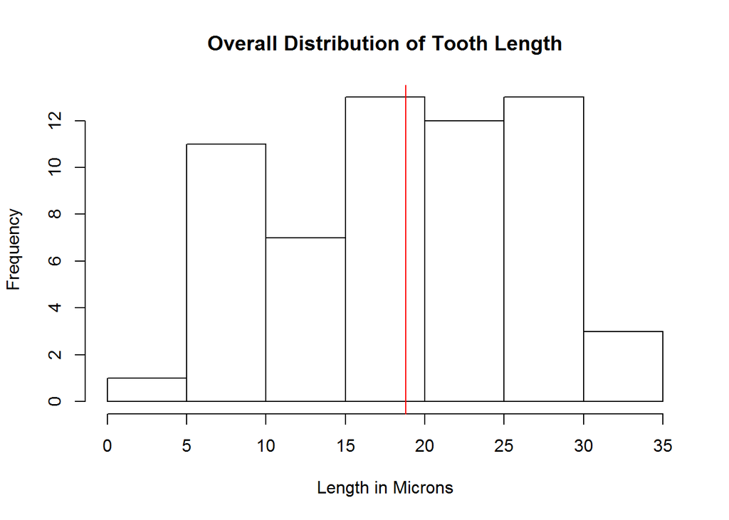

```r
hist(ToothGrowth$len, main = "Overall Distribution of Tooth Length", xlab = "Length in Microns")
abline(v = mean(ToothGrowth$len) , col = "red")
```

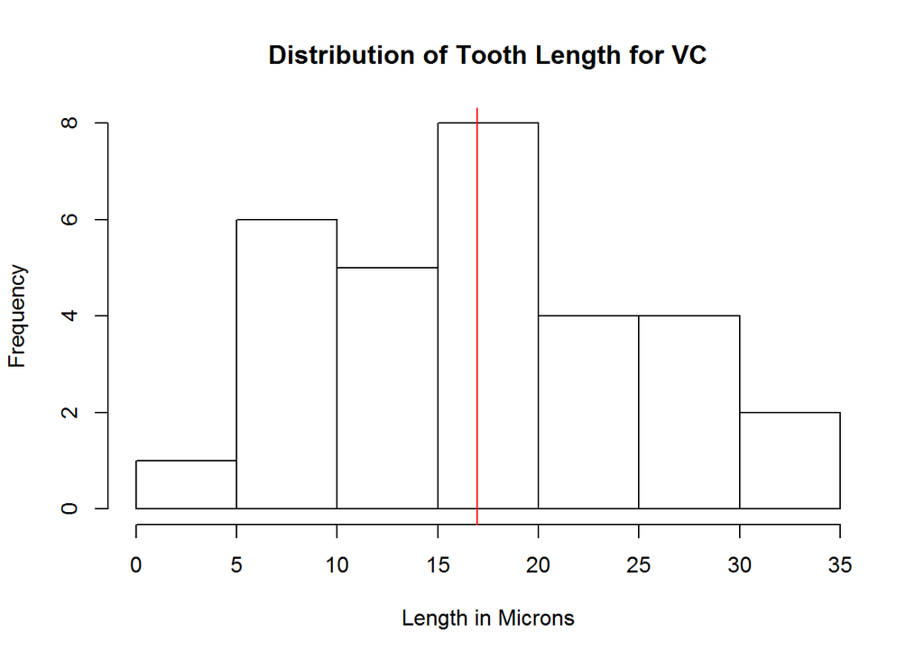

```r
VClen <- subset(ToothGrowth, supp == "VC", select = "len")
hist(VClen$len, main = "Distribution of Tooth Length for VC", xlab = "Length in Microns")
abline(v=mean(VClen$len), col = "red")
```

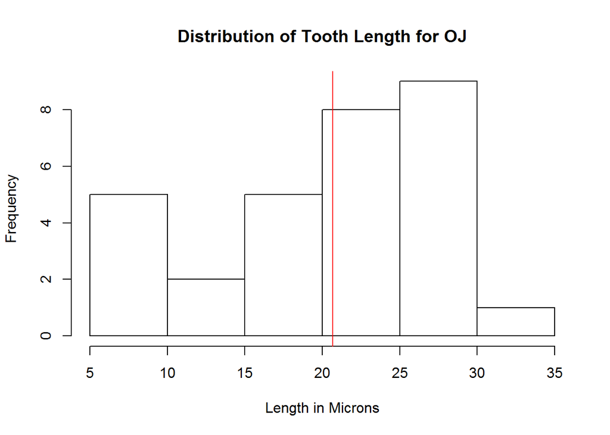

```r
OJlen <- subset(ToothGrowth, supp == "OJ", select = "len")
hist(OJlen$len, main = "Distribution of Tooth Length for OJ", xlab = "Length in Microns")
abline(v=mean(OJlen$len), col = "red")
```

The overall distribution of tooth length looks normal-ish, though the dip in frequency between 10 and 15 is interesting.

Comparing the tooth lengths between VC and OJ, the VC distribution appears normal-ish as well, but the OJ distirbution is skewed toward the higher end.

Now, let’s look at the distribution of the various dosage levels.

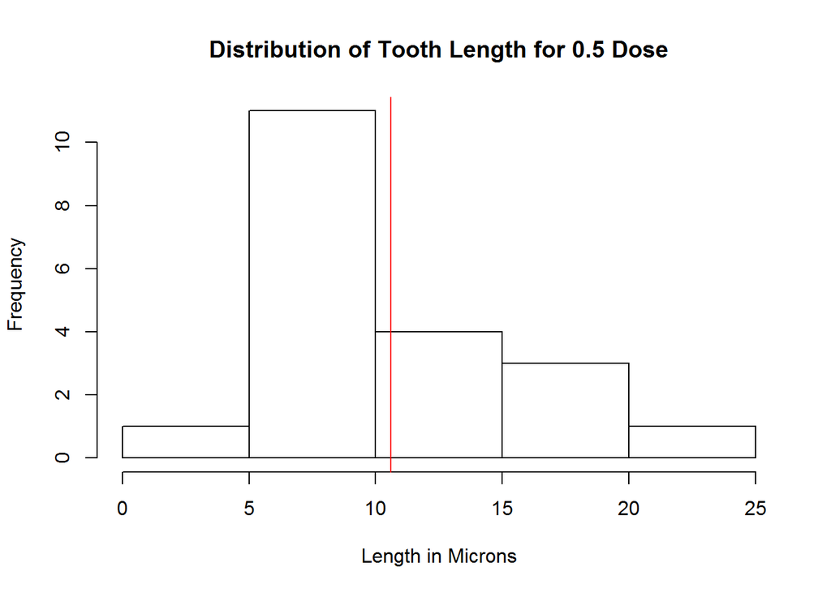

```r
zerofivelen <- subset(ToothGrowth, dose == "0.5", select = "len")
hist(zerofivelen$len, main = "Distribution of Tooth Length for 0.5 Dose", xlab = "Length in Microns")
abline(v=mean(zerofivelen$len), col = "red")
```

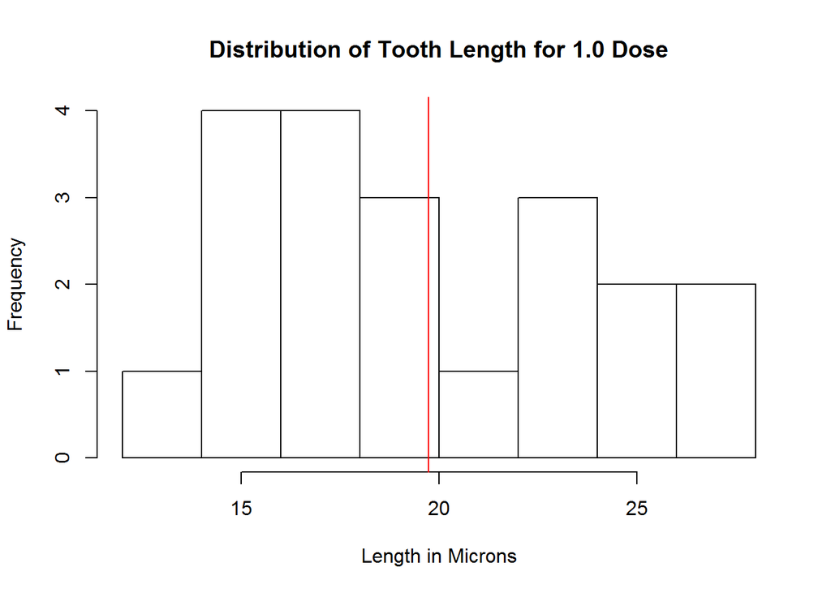

```r
onezerolen <- subset(ToothGrowth, dose == "1", select = "len")
hist(onezerolen$len, main = "Distribution of Tooth Length for 1.0 Dose", xlab = "Length in Microns")
abline(v=mean(onezerolen$len), col = "red")
```

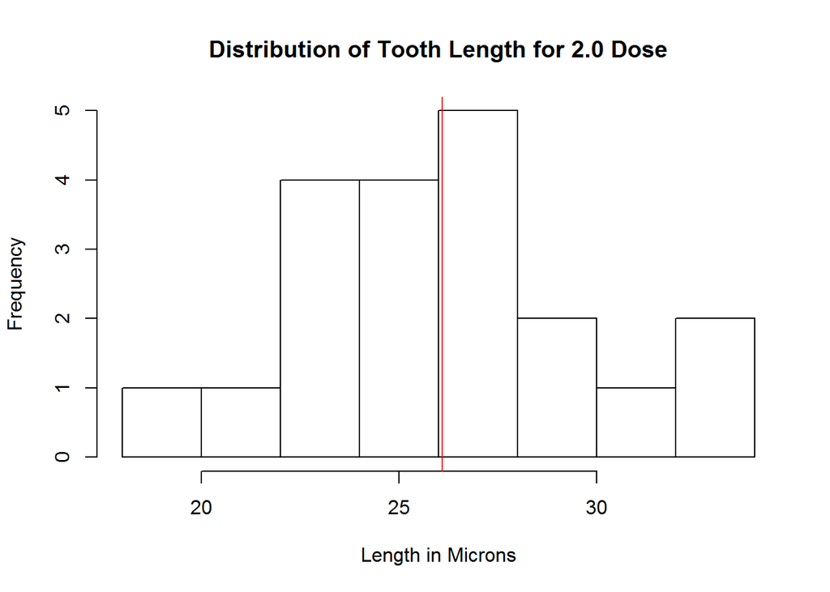

```r
twozerolen <- subset(ToothGrowth, dose == "2", select = "len")
hist(twozerolen$len, main = "Distribution of Tooth Length for 2.0 Dose", xlab = "Length in Microns")
abline(v=mean(twozerolen$len), col = "red")
```

The .05 distribution is concentrated towards the lower end, with over ten observations between 5 and 10 microns. The 1.0 distribution appears bimodal, with peaks between 15 and 20 microns, then a smaller peak between 20 and 25 microns. The 2.0 distribution is the most normal looking of the three, though does have a little pick up near the top end, with two observations in the 34 micron range.

# Summarize the Data

To further understand the tooth length data along by supplement method and dosage, we will find the average tooth length and standard deviation by supplement method, by dosage level and both supplement method and dosage level.

```r
growthBySupp <- summarize(group_by(ToothGrowth, supp), mean(len), sd(len))
colnames(growthBySupp) <- c("supp", "meanlen", "sdlen")
growthBySupp
```

```
## Source: local data frame [2 x 3]
##
##   supp  meanlen    sdlen
## 1   OJ 20.66333 6.605561
## 2   VC 16.96333 8.266029
```

```r
growthByDose <- summarize(group_by(ToothGrowth, dose), mean(len), sd(len))
colnames(growthByDose) <- c("supp", "meanlen", "sdlen")
growthByDose
```

```
## Source: local data frame [3 x 3]
##
##   supp meanlen    sdlen
## 1  0.5  10.605 4.499763
## 2  1.0  19.735 4.415436
## 3  2.0  26.100 3.774150
```

```r
growthBySuppAndDose <- summarize(group_by(ToothGrowth, supp, dose), mean(len), sd(len))
colnames(growthBySuppAndDose) <- c("supp", "dose", "meanlen", "sdlen")
growthBySuppAndDose
```

```
## Source: local data frame [6 x 4]
## Groups: supp
##
##   supp dose meanlen    sdlen
## 1   OJ  0.5   13.23 4.459709
## 2   OJ  1.0   22.70 3.910953
## 3   OJ  2.0   26.06 2.655058
## 4   VC  0.5    7.98 2.746634
## 5   VC  1.0   16.77 2.515309
## 6   VC  2.0   26.14 4.797731
```

Looking at the summary of tooth growth supplement, the mean of of OJ is higher than that of VC and has a tighter standard deviation, which suggests this supplement may be more effective at growing teeth.

Generally, the higher the dose, the greater the tooth growth and the tighter the standard deviation, suggesting that greater doses may be more effective at growing teeth.

# Testing Tooth Growth

The data shows tooth growth by two dimensions: delivery method and doses. Since the sample sizes are relatively small, we’ll use the T distribution to compare our hypotheses.

The first hypothesis we’ll test is that the supplemental delivery method OJ, the alternative hypothesis, has a greater impact on tooth growth than VC, the null hypothesis. Since the exploratory analysis above suggested that tooth lenght with the OJ supplement tended to have more observations with longer tooth lengths than the VC supplement, let’s look deeper into this data.

```r
growthVC <- subset(ToothGrowth, supp == "VC", select = "len")
growthOJ <- subset(ToothGrowth, supp == "OJ", select = "len")
t.test(growthOJ - growthVC, var.equal = TRUE)
```

```
##
##  One Sample t-test
##
## data:  growthOJ - growthVC
## t = 3.3026, df = 29, p-value = 0.00255
## alternative hypothesis: true mean is not equal to 0
## 95 percent confidence interval:
##  1.408659 5.991341
## sample estimates:
## mean of x
##       3.7
```

The hypothesis test reveals a 95% confidence interval of 1.4086586, 5.9913414. As this interval is entirely above zero, we can reasonably conclude that the OJ supplement does indeed have a greater impact on tooth growth than the and we can accept the alternative hypothesis.

Now, let’s have closer look at the dose data. We’ll test two hypotheses: 1. The 1.0 dose has a greater impact on tooth growth than the 0.5 dose. 2. The 2.0 does has a greater impact on tooth growth than the 1.0 dose.

```r
growth0.5 <- subset(ToothGrowth, dose == "0.5", select = "len")
growth1.0 <- subset(ToothGrowth, dose == "1", select = "len")
t.test(growth1.0 - growth0.5, var.equal = TRUE)
```

```
##
##  One Sample t-test
##
## data:  growth1.0 - growth0.5
## t = 6.9669, df = 19, p-value = 1.225e-06
## alternative hypothesis: true mean is not equal to 0
## 95 percent confidence interval:
##   6.387121 11.872879
## sample estimates:
## mean of x
##      9.13
```

This hypothesis test reveals a 95% confidence interval of 6.3871212, 11.8728788. As the previous exploratory analysis suggested, increasing the dosage by .5 leads to significantly more tooth growth. What about the impact of increasing from 1.0 to 2.0?

```r
growth2.0 <- subset(ToothGrowth, dose == "2", select = "len")
t.test(growth2.0 - growth1.0, var.equal = TRUE)
```

```
##
##  One Sample t-test
##
## data:  growth2.0 - growth1.0
## t = 4.6046, df = 19, p-value = 0.0001934
## alternative hypothesis: true mean is not equal to 0
## 95 percent confidence interval:
##  3.471814 9.258186
## sample estimates:
## mean of x
##     6.365
```

# Conclusions and Assumptions

The exploration and testing of the ToothGrowth data above points us to a few conclusions

1. As a general rule, we can conclude from our that the OJ supplement is more leads to greater tooth growth than the VC supplement assuming vitamin C was the only tooth growing nutrient the subjects ingested during the experiment time period.
2. The OJ supplement is more reliable at higher doses and the VC supplement is more reliable at lower doses assuming standard deviation is a valid measure of reliability for the supplements in question.
3. Continuing to increase the dosage will eventually reach the point of diminishing returns as it pertains to tooth growth, assuming large doses follow the pattern observed above of successively large doses yielding successively smaller tooth growth results.